# Introduction to CMAP with R

Andrew Irwin

November 2019

## Goals

This document is a tutorial introduction to using CMAP with R. The code is written in R, but many of the examples will translate easily into python examples if you are familiar with the python library for accessing CMAP. After providing a brief introduction to CMAP, my goals are to illustrate how to

- get started with CMAP
- learn about the data in the CMAP database
- use some of the tools in the `cmap4r` package to access data
- design your own database queries to customize the data you obtain.

I illustrate the examples using data from

- MIT GCM/Darwin output
- satellite remote-sensing chlorophyll
- molecular taxonomy at SPOT
- Pisces model output

## What is CMAP?

The [Simons Collaborative Marine Atlas Project](https://simonscmap.com/) (CMAP) is a tool for organizing and accessing oceanographic data. Much of the data is associated with investigators in the Simons projects (SCOPE, Gradients, and CBIOMES).

CMAP is also a set of software tools for accessing, analyzing, and displaying the data. The heterogeneous nature of the dataset motivated the creation of tools for unifying data from these disparate sources to facilitate analysis and synthesis.

The system is open and intended to be of use widely in the oceanographic research community.

While CMAP contains many data sources, it is not a repository such as zenodo, dryad, figshare, or pangaea. The CMAP metadata for each table reports where the reference for each dataset is deposited. CMAP is not intended for data that are not geolocated, such as taxonomic data provided by services like marinespecies.org.

## Installation and basic usage

CMAP has a [web page](https://cmap.readthedocs.io/en/latest/) describing the various software tools for accessing and using the data.

The R package is documented [here](https://github.com/simonscmap/cmap4r) and can be installed from github using

```
devtools::install_github("simonscmap/cmap4r/cmap4r")
set_authorization()
```

You will need to obtain an API key from the [CMAP website](https://simonscmap.com/) to query the database.

## What data are available?

All data are stored in tables. Each table has variables (columns) with latitude, longitude, depth, and time, plus all the specific variables associated with that dataset. There are metadata available for all tables and variables. Exploring these metadata will help you get to know what data are available.

The catalog of tables and metadata is available from the `get_catalog` function.

```r
get_catalog() -> catalog
```

The catalog has metadata including:

- a long name for the variable,
- units,
- information on the type and sampling method for the data (physics, chemistry, biology; cruises, model, satellite),
- the spatial and temporal resolution and extent,
- the number of obeservations, and mean, standard deviation, and quantiles (min, 25, 50, 75, max) of the data,
- repository information,
- and other descriptive metadata.

This is a large table with 1093 rows and 34 columns, so some summary statistics would be helpful. Here are the number of tables of data, total number of variables, and total number of observations in the whole CMAP database.

```r
catalog %>% group_by(Table_Name) %>%
  summarize(number_variables = n(),
            Variable_Count = sum(Variable_Count)) %>%
  ungroup() %>%
  summarize(number_tables = n(),
            mean_variables_per_table = mean(number_variables),
            total_variables = sum(number_variables),
            total_observations = sum(Variable_Count, na.rm=TRUE)) %>%
  pivot_longer(1:4, names_to = "Statistic", values_to="Number") %>%
  mutate(Number = prettyNum(signif(Number,4), big.mark=","))
```

| Statistic | Number |
| --- | --- |
| number_tables | 69 |
| mean_variables_per_table | 15.84 |
| total_variables | 1,093 |
| total_observations | 4.276e+11 |

Much of this data is gridded model output. We can break the sums down into categories like this:

```r
catalog %>% group_by(Make, Sensor, Table_Name) %>%
  summarize(number_variables = n(),
            Variable_Count = sum(Variable_Count)) %>%
  group_by(Make, Sensor) %>%
  summarize(number_tables = n(),
            total_variables = sum(number_variables),
            total_observations = sum(Variable_Count, na.rm=TRUE)) %>%
  arrange(-total_observations) %>%
  mutate(total_observations = prettyNum(total_observations, big.mark=","))
```

| Make | Sensor | number_tables | total_variables | total_observations |
| --- | --- | --- | --- | --- |
| Model | Blend | 9 | 131 | 352,005,305,737 |
| Observation | Satellite | 9 | 34 | 74,264,617,087 |
| Observation | In-Situ | 43 | 760 | 742,617,507 |
| Observation | Drifter | 1 | 8 | 299,697,516 |
| Observation | Float | 1 | 87 | 276,283,565 |
| Observation | CTD | 2 | 26 | 1,041,962 |
| Observation | Optical | 2 | 16 | 72,430 |
| Observation | Flow Cytometry | 1 | 22 | 0 |
| Observation | Underway CTD | 1 | 9 | 0 |

There are over 700 million in-situ measurements. Looking at only in situ data with detail for the 7 largest categories, we see the following:

```r
catalog %>%
  filter(Sensor == "In-Situ") %>%
  group_by(Table_Name) %>%
  summarize(number_variables = n(),
            Variable_Count = sum(Variable_Count)) %>%
  mutate(Table_Name = fct_lump(Table_Name, n=7,
                            w = replace_na(Variable_Count,0))) %>%
  group_by(Table_Name) %>%
  summarize(number_variables = sum(number_variables),
            Variable_Count = sum(Variable_Count, na.rm=TRUE)) %>%
  arrange(-Variable_Count) %>%
  mutate(Variable_Count = prettyNum(signif(Variable_Count,4), big.mark=","))
```

| Table_Name | number_variables | Variable_Count |
| --- | --- | --- |
| tblWOA_Climatology | 48 | 680,500,000 |
| tblGLODAP | 48 | 56,400,000 |
| tblKM1906_Gradients3_uw_tsg | 2 | 3,217,000 |
| tblCruise_Salinity | 1 | 1,198,000 |
| tblHOT_Bottle | 61 | 756,600 |
| tblHOT_CTD | 9 | 211,600 |
| Other | 586 | 204,900 |
| tblGlobal_PicoPhytoPlankton | 5 | 95,470 |

Here is a function `search_metadata` that allows a keyword (regular expression) search of the main descriptive columns and returns a subset of the metadata file to help you discover data available in CMAP. By default only the “long name” column is searched. To search a broader set of text columns set `long_name_only = FALSE`.

```r
search_metadata = function(s, all_metadata=catalog, long_name_only=TRUE) {
  i <- grep(s, all_metadata$Long_Name)
  if (!long_name_only) i <- i %>%
       union(grep(s, all_metadata$Unit)) %>%
       union(grep(s, all_metadata$Dataset_Name)) %>%
       union(grep(s, all_metadata$Dataset_Description)) %>%
       union(grep(s, all_metadata$Keywords)) %>%
       union(grep(s, all_metadata$Temporal_Resolution)) %>%
       union(grep(s, all_metadata$Spatial_Resolution))
  all_metadata[i,]
}
search_metadata("chl") %>% head()
```

| Variable | Table_Name | Long_Name | Unit | Make | Sensor | Process_Level | Study_Domain | Temporal_Resolution | Spatial_Resolution | Time_Min | Time_Max | Lat_Min | Lat_Max | Lon_Min | Lon_Max | Depth_Min | Depth_Max | Variable_25th | Variable_50th | Variable_75th | Variable_Count | Variable_Mean | Variable_Std | Variable_Min | Variable_Max | Comment | Dataset_Name | Data_Source | Distributor | … |
| --- | --- | --- | --- | --- | --- | --- | --- | --- | --- | --- | --- | --- | --- | --- | --- | --- | --- | --- | --- | --- | --- | --- | --- | --- | --- | --- | --- | --- | --- | --- |
| prochlorococcus_hot | tblHOT_PP | Prochlorococcus | #/ml | Observation | In-Situ | Reprocessed | Biogeochemistry | Irregular | Irregular | 1988-10-31 | 2016-10-15 | 22.75000 | 22.75000 | -158.0000 | -158.0000 | 0 | 178 | 30349.0000 | 1.27893e+05 | 202414.5000 | 1567 | 1.238267e+05 | 9.268443e+04 | 44.0000 | 3.6940e+05 | NA | Primary Production HOT | Hawaii Ocean Time-series (HOT) | http://hahana.soest.hawaii.edu/hot/hot-dogs/ | … |
| prochlorococcus_bottle_hot | tblHOT_Bottle | Prochlorococcus | # x 105/ml | Observation | In-Situ | Reprocessed | Biogeochemistry | Irregular | Irregular | 1988-10-31 | 2016-11-29 | 21.84700 | 22.75000 | -158.3630 | -157.9000 | NA | NA | 0.2300 | 1.08300e+00 | 1.9465 | 2070 | 1.154478e+00 | 9.191500e-01 | 0.0000 | 3.7240e+00 | NA | Bottle Data HOT | Hawaii Ocean Time-series (HOT) | http://hahana.soest.hawaii.edu/hot/hot-dogs/ | … |
| chlpig_cmore | tblBottle_Chisholm | CTD chloropigment | ug/l | Observation | In-Situ | Reprocessed | Chemistry+Biology+Biogeochemistry | Three Minutes | Irregular | 2010-11-19 | 2010-12-12 | -26.24898 | -20.08218 | -104.2543 | -70.7997 | 2 | 1992 | 0.0689 | 1.57350e-01 | 0.4535 | 3364 | 3.281512e-01 | 4.098705e-01 | 0.0492 | 4.2812e+00 | From http://hahana.soest.hawaii.edu/cmoreDS/bextraction.html | BiGRAPA1: Prochlorococcus abundance and associated (bottle) metadata | C-MORE, Chisholm Lab | https://chisholmlab.mit.edu/ | … |
| chlda_cmore | tblBottle_Chisholm | chlorophyllide a | ng/L | Observation | In-Situ | Reprocessed | Chemistry+Biology+Biogeochemistry | Three Minutes | Irregular | 2010-11-19 | 2010-12-12 | -26.24898 | -20.08218 | -104.2543 | -70.7997 | 2 | 1992 | 0.0000 | 0.00000e+00 | 0.0000 | 172 | 1.506977e+00 | 7.352523e+00 | 0.0000 | 5.9600e+01 | From http://hahana.soest.hawaii.edu/cmoreDS/bextraction.html | BiGRAPA1: Prochlorococcus abundance and associated (bottle) metadata | C-MORE, Chisholm Lab | https://chisholmlab.mit.edu/ | … |
| chlplus_cmore | tblBottle_Chisholm | chlorophyll c | ng/L | Observation | In-Situ | Reprocessed | Chemistry+Biology+Biogeochemistry | Three Minutes | Irregular | 2010-11-19 | 2010-12-12 | -26.24898 | -20.08218 | -104.2543 | -70.7997 | 2 | 1992 | 0.0000 | 0.00000e+00 | 24.3000 | 172 | 2.012907e+01 | 4.070116e+01 | 0.0000 | 2.2210e+02 | From http://hahana.soest.hawaii.edu/cmoreDS/bextraction.html | BiGRAPA1: Prochlorococcus abundance and associated (bottle) metadata | C-MORE, Chisholm Lab | https://chisholmlab.mit.edu/ | … |
| chlb_cmore | tblBottle_Chisholm | chlorophyll b | ng/L | Observation | In-Situ | Reprocessed | Chemistry+Biology+Biogeochemistry | Three Minutes | Irregular | 2010-11-19 | 2010-12-12 | -26.24898 | -20.08218 | -104.2543 | -70.7997 | 2 | 1992 | 0.0000 | 1.86500e+01 | 67.6000 | 172 | 4.407907e+01 | 5.701559e+01 | 0.0000 | 2.4820e+02 | From http://hahana.soest.hawaii.edu/cmoreDS/bextraction.html | BiGRAPA1: Prochlorococcus abundance and associated (bottle) metadata | C-MORE, Chisholm Lab | https://chisholmlab.mit.edu/ | … |

Here is a function that selects the main descriptive columns about a table.

Get dataset info: table name, long name, range and resolution of each axis, citation, source

```r
table_info = function(tbl = "tblCHL_REP", all_metadata = catalog) {
  all_metadata %>% filter(Table_Name == tbl) %>% slice(1) %>%
    mutate(Spatial_Range = paste("Latitude [", round(Lat_Min, 2), ", ", round(Lat_Max, 2), "], ",
                               "Longitude [", round(Lon_Min, 2), ", ", round(Lon_Max, 2), "], ",
                               "Depth [", round(Depth_Min, 2), ", ", round(Depth_Max,2 ), "]"),
           Time_Range = paste("[", Time_Min, ", ", Time_Max, "]")) %>%
  select(Table_Name, Make, Sensor, Temporal_Resolution, Spatial_Resolution,
         Spatial_Range, Time_Range,
         Dataset_Name, Data_Source, Distributor) %>%
  pivot_longer(everything(), names_to="Description", values_to="Value")
}
table_info("tblBottle_Chisholm")
```

| Description | Value |
| --- | --- |
| Table_Name | tblBottle_Chisholm |
| Make | Observation |
| Sensor | In-Situ |
| Temporal_Resolution | Three Minutes |
| Spatial_Resolution | Irregular |
| Spatial_Range | Latitude [ -26.25 , -20.08 ], Longitude [ -104.25 , -70.8 ], Depth [ 2 , 1992 ] |
| Time_Range | [ 2010-11-19 , 2010-12-12 ] |
| Dataset_Name | BiGRAPA1: Prochlorococcus abundance and associated (bottle) metadata |
| Data_Source | C-MORE, Chisholm Lab |
| Distributor | https://chisholmlab.mit.edu/ |

## Getting data

The `cmap4r` package defines several functions for querying a table in the database. These functions vary according to the amount of averaging done on the CMAP server. More processing done remotely means less data needs to be sent to you, so if you don’t need the full resolution of the data, it’s a good idea to use the right averaging query. I’ll start by illustrating several functions to extract and aggregate data: `get_section`, `get_depthprofile`, `get_spacetime`, and `get_timeseries`. Since CMAP organizes data in relational database you can query with SQL. Later I will demonstrate several queries you can write to group and summarize data in a variety of ways.

I’ll demonstrate the following features of the SQL SELECT query

- basic select statements and the modifiers `top()` and `distinct`
- changing the name of selected variables
- summary functions `count`, average, standard deviatio, and how to count missing data
- `where` to restrict the query to part of the data
- `group by` to define aggregation level
- `having to`: filter out rows by a logical condition
- joins to combine data from multiple tables

There are lots of other things you can do with select, but these are emphasized because they will help reduce the amount of data that needs to be transmitted to you from the server, saving you time.

### Warming up

If you want to see what is in a table, without thinking about what time or space region to query, just get the “head” or top $n$ lines of the table:

```r
get_head("tblESV", nrows=8)
```

| time | lat | lon | depth | centroid | relative_abundance | max_abundance | cluster_level | num_cluster_members | domain | phylum | class | order | genus | species | esv_temperature | esv_salinity | esv_chl | size_frac_lower | size_frac_upper | cruise_name | prok_cells_10E05_per_ml |
| --- | --- | --- | --- | --- | --- | --- | --- | --- | --- | --- | --- | --- | --- | --- | --- | --- | --- | --- | --- | --- | --- |
| 2012-04-13 | -45.0943 | -58.1635 | 60 | 26e3eea22777b2b388adcb458f6e6430 | 0.0000000000 | 0.0002347339 | 100 | 0 | Bacteria | Proteobacteria | Gammaproteobacteria | Francisellales | Francisella | uncultured bacterium | 9.8878 | 33.9984 | 0.289 | 8 | NA | ANT28-5 | 8.54 |
| 2012-04-13 | -45.0943 | -58.1635 | 60 | fe63fa5adae4f6ceda3cbf3d97353f8a | 0.0000000000 | 0.0002347339 | 100 | 0 | Bacteria | Proteobacteria | Deltaproteobacteria | Myxococcales | uncultured | NA | 9.8878 | 33.9984 | 0.289 | 8 | NA | ANT28-5 | 8.54 |
| 2012-04-13 | -45.0943 | -58.1635 | 60 | f1b1b2d302ddc5774cdab6644dba94b9 | 0.0000000000 | 0.0002347339 | 100 | 0 | Bacteria | Proteobacteria | Alphaproteobacteria | Rhodospirillales | Magnetospira | uncultured bacterium | 9.8878 | 33.9984 | 0.289 | 8 | NA | ANT28-5 | 8.54 |
| 2012-04-13 | -45.0943 | -58.1635 | 60 | 7aae41611a64fffc28e8520b8523db84 | 0.0000000000 | 0.0002347339 | 100 | 0 | Bacteria | NA | NA | NA | NA | NA | 9.8878 | 33.9984 | 0.289 | 8 | NA | ANT28-5 | 8.54 |
| 2012-04-13 | -45.0943 | -58.1635 | 60 | 264e65eb7044ca6c2494454845ac9a70 | 0.0001139861 | 0.0002345216 | 100 | 0 | Bacteria | Bacteroidetes | Bacteroidia | Flavobacteriales | Ambiguous_taxa | Ambiguous_taxa | 9.8878 | 33.9984 | 0.289 | 8 | NA | ANT28-5 | 8.54 |
| 2012-04-13 | -45.0943 | -58.1635 | 60 | 09467c9aae04e7c6c737645fd961c05d | 0.0000000000 | 0.0002345216 | 100 | 0 | Bacteria | Bacteroidetes | Bacteroidia | Flavobacteriales | NA | NA | 9.8878 | 33.9984 | 0.289 | 8 | NA | ANT28-5 | 8.54 |
| 2012-04-13 | -45.0943 | -58.1635 | 60 | f05ced46f67bce11377574e705f0b3f5 | 0.0000000000 | 0.0002345216 | 100 | 0 | Bacteria | Proteobacteria | Deltaproteobacteria | Bdellovibrionales | Peredibacter | NA | 9.8878 | 33.9984 | 0.289 | 8 | NA | ANT28-5 | 8.54 |
| 2012-04-13 | -45.0943 | -58.1635 | 60 | b9922043df016e1d965192a3617b4840 | 0.0001424826 | 0.0002344916 | 100 | 0 | Bacteria | Proteobacteria | Alphaproteobacteria | Parvibaculales | NA | NA | 9.8878 | 33.9984 | 0.289 | 8 | NA | ANT28-5 | 8.54 |

How much data is in the table? Create a query to count the data. (More on these queries later on.)

```r
mq = glue("select count(*) as n from tblESV")
exec_manualquery(mq)
```

| n |
| --- |
| 9319750 |

At present there are 9,319,750 rows, so it would take a long time to get them all!

### Basic queries

The raw retrieval format will send you all the data for a particular variable in a 4 dimensional (lat, lon, depth, time) box. It is easy to write a request for a lot of data which will take a long time to be transferred to you. You can always request a summary of how much data is to be sent before you get the data itself, so you know what to expect.

```r
tableName <- "tblPisces_NRT"
varName <- "NO3"
lat1 = 10; lat2 = 60
lon1 = -160; lon2 = -158
dt1 = "2016-04-30"; dt2 = "2016-04-30"
depth1 <- 0; depth2 =  5000
```

Peek into the table to see what is there

```r
get_head(tableName)
```

| depth | lat | lon | time | Fe | PP | Si | NO3 | CHL | PHYC | PO4 | O2 | month | year |
| --- | --- | --- | --- | --- | --- | --- | --- | --- | --- | --- | --- | --- | --- |
| 130.666 | 11 | -174.0 | 2017-12-09 | 4.858432e-05 | 0.0001535153 | 18.61868 | 12.15407 | 0.1706367 | 0.4235890 | 1.111577 | 162.6138 | 12 | 2017 |
| 130.666 | 11 | -173.5 | 2017-12-09 | 3.881681e-05 | 0.0001554765 | 17.37639 | 11.09769 | 0.1797488 | 0.4477850 | 1.047352 | 167.5350 | 12 | 2017 |
| 130.666 | 11 | -173.0 | 2017-12-09 | 4.018125e-05 | 0.0001441072 | 16.92915 | 10.64967 | 0.1647004 | 0.4107051 | 1.012221 | 170.9505 | 12 | 2017 |
| 130.666 | 11 | -172.5 | 2017-12-09 | 3.840859e-05 | 0.0001265818 | 16.86999 | 10.61158 | 0.1511148 | 0.3745859 | 1.018020 | 170.4261 | 12 | 2017 |
| 130.666 | 11 | -172.0 | 2017-12-09 | 3.591507e-05 | 0.0001221834 | 17.00548 | 10.89364 | 0.1484451 | 0.3674750 | 1.043450 | 168.0933 | 12 | 2017 |

Before we make the query, let’s find out how much data would match this query.

```r
mq = glue("select count(*) as n from {tableName} where [time] between '{dt1}' and '{dt2}' and
                    lat between {lat1} and {lat2} and
                    lon between {lon1} and {lon2} and
                    depth between {depth1} and {depth2}")
exec_manualquery(mq)
```

| n |
| --- |
| 24240 |

### Built-in get_* queries

Now get the data – there is quite a bit of data, so this may take the better part of a minute.

```r
tbl.subset <- get_section(tableName, varName, lat1, lat2, lon1, lon2,
                   dt1, dt2, depth1, depth2)
```

Other query fuctions are:

- get_depthprofile - this averages over the time, latitude, and longitude window specified, returning a 1-d depth profile
- get_timeseries - this averages over space, returning a 1-d time series
- get_spacetime - this does the same thing as `get_section` returning a 3-d subset defined by the time, latitude, and longitude windows

Here are examples of each.

```r
tableName <- "tblDarwin_Ecosystem"
table_info(tableName)
```

| Description | Value |
| --- | --- |
| Table_Name | tblDarwin_Ecosystem |
| Make | Model |
| Sensor | Blend |
| Temporal_Resolution | Three Days |
| Spatial_Resolution | 1/2° X 1/2° |
| Spatial_Range | Latitude [ -89.75 , 89.75 ], Longitude [ -179.75 , 179.75 ], Depth [ 5 , 5906.25 ] |
| Time_Range | [ 1993-12-31 , 2015-12-30 ] |
| Dataset_Name | Darwin Biogeochemistry 3 Day Averaged Model of Bulk Ecosystem Characteristics |
| Data_Source | http://darwinproject.mit.edu |
| Distributor | http://darwinproject.mit.edu |

```r
varName <- "phytoplankton"
lat1 <- 20; lat2 <- 50
lon1 <- -145; lon2 <- -175
dt1 <- '2000-05-01'; dt2 <- '2000-06-30'
depth1 <- 0; depth2 <- 50
# tableName <- "tblDarwin_Nutrient"
tbl.depth <- get_depthprofile(tableName, varName, lat1, lat2, lon1, lon2,
                               dt1, dt2, depth1, depth2)
tbl.timeseries <- get_timeseries(tableName, varName, lat1, lat2, lon1, lon2,
                               dt1, dt2, depth1, depth2)
tbl.spacetime <- get_spacetime(tableName, varName, lat1+10, lat2-10, lon1-10, lon2+10,
                               dt1, dt2, depth1, depth2)
```

### Writing your own queries for data

You can write your own custom database query in SQL and use the `exec_manualquery` function to retrieve the data. I’ll gradually show how to explore the database through a sequence of examples.

It’s often a good idea to make a query that you know will have a small amount of data returned as an example before you perform a comprehensive request for all the data you want. Two ways to do this are to count the number of rows (observations) resulting from a query, or to show just a sample of the results. The keyword `distinct` removes duplicates. Instead of `top()` you can use `order by newid()` to sample rows apparently at random so you don’t just get the first few rows.

```r
mq = "select count(lat) as n from tblESV where domain != 'Bacteria'"
exec_manualquery(mq)
```

| n |
| --- |
| 159220 |

Here are a bunch of examples tht illustrate counting (‘count’), obtaining selected entries (‘distinct’, ‘top’), filtering (‘where’), ordering output (‘order by’), and grouping output for summaries (‘count’ .. ‘group by’). I’ll only execute the last one. Go ahead and try each of them to work out how the queries operate.

```r
mq = "select concat('Number of observations ', str(count(lat))) as summary from tblESV where domain != 'Bacteria'"
mq = "select distinct domain from tblESV where domain != 'Bacteria'"
mq = "select top(10) * from tblESV"
mq = "select top(10) * from tblESV order by newid()"  # samples from the database
mq = "SELECT count(lat) FROM tblESV WHERE [time] BETWEEN '2012-04-01' AND '2017-06-03' "
mq = "select domain, count(*) from tblESV group by domain"
a <- exec_manualquery(mq)
a
```

| domain | X2 |
| --- | --- |
| Bacteria | 9160530 |
| Archaea | 158310 |
| Unassigned | 910 |

A query is constructed using the “select” command. You must specify what variables (columns from a table) you are selecting or functions of those variables. Then you specify what table to find those variables. The “where” clause allows you to specify a subset of the full table; here we get all data in a specified range of latitudes, longitudes, and times. We “group by” latitude and time, which means we will compute means over all longitudes in the selected region. Finally we organize the output (“order by”) time and latitude.

Here is a query to find the sample size (n), mean, and standard deviation for chlorophyll averaged over a latitude-longitude box

```r
mq = glue("select [time], lat, count(chl) as chl_n, avg(chl) as chl_mean, stdev(chl) as chl_sd
                  from tblCHL_REP where [time] between '2016-01-01' and '2016-12-31' and
                                           lat between 40 and 50 and
                                           lon between 50 and 60
                                           group by lat, [time]
                                           order by [time], lat
                                           ")
a <- exec_manualquery(mq)
head(a)
```

| time | lat | chl_n | chl_mean | chl_sd |
| --- | --- | --- | --- | --- |
| 2016-01-01 | 40.125 | 12 | 2.3730654 | 0.8306405 |
| 2016-01-01 | 40.375 | 11 | 2.4872121 | 0.6979687 |
| 2016-01-01 | 40.625 | 17 | 1.8198676 | 1.2680987 |
| 2016-01-01 | 40.875 | 20 | 1.1819661 | 0.7836411 |
| 2016-01-01 | 41.125 | 19 | 0.9302335 | 0.6544863 |
| 2016-01-01 | 41.375 | 18 | 1.0941463 | 0.8984575 |

You have a lot of freedom for the grouping variable. For example, here we round latitude to one decimal place and compute the floor of (largest integer less than) longitude and use those as grouping variables. We report the mean latitude and longitude in the grouping box. We can count the number of chlorophyll observations and the number of missing data. (count(*) reports all rows, including missing data; count(chl) counts only non-missing data.)

```r
mq = glue("select avg(lat) as mean_lat, avg(lon) as mean_lon, count(chl) as n, count(*)-count(chl) as n_na, avg(chl) as mean,
                  stdev(chl) as sd
                  from tblCHL_REP
                  where [time] between '2016-01-01' and '2016-12-31' and
                                           lat between 40 and 50 and
                                           lon between 50 and 60
                  group by round(lat,1), floor(lon)
                  having count(chl) > 0
            ")
a <- exec_manualquery(mq)
head(a)
```

| mean_lat | mean_lon | n | n_na | mean | sd |
| --- | --- | --- | --- | --- | --- |
| 46.125 | 52.5 | 149 | 35 | 3.858699 | 3.5814684 |
| 41.625 | 50.5 | 181 | 3 | 1.898825 | 1.4471153 |
| 45.875 | 53.5 | 26 | 158 | 10.335555 | 5.1259967 |
| 45.375 | 59.5 | 85 | 99 | 6.137682 | 5.4809482 |
| 41.375 | 51.5 | 178 | 6 | 1.475527 | 0.5725362 |
| 46.625 | 51.5 | 167 | 17 | 6.696483 | 5.5840638 |

By adjusting the group by variables, you can get any rounding you like. For example, here we average over 2x2 degree boxes.

```r
mq = glue("select avg(lat) as mean_lat, avg(lon) as mean_lon, count(chl) as n, count(*)-count(chl) as n_na, avg(chl) as mean,
                  stdev(chl) as sd
                  from tblCHL_REP
                  where [time] between '2016-01-01' and '2016-12-31' and
                                           lat between 40 and 50 and
                                           lon between 50 and 60
                  group by round((lat-0.5)/2,0)*2+0.5, round((lon-0.5)/2,0)*2+0.5
                  having count(chl) > 0
                  order by mean_lat, mean_lon
            ")
a <- exec_manualquery(mq)
head(a)
```

| mean_lat | mean_lon | n | n_na | mean | sd |
| --- | --- | --- | --- | --- | --- |
| 40.75 | 50.75 | 1637 | 19 | 1.909514 | 0.9900151 |
| 40.75 | 52.50 | 1883 | 325 | 1.266899 | 0.8942297 |
| 40.75 | 54.50 | 812 | 1396 | 0.356574 | 0.3635207 |
| 40.75 | 56.50 | 2 | 2206 | 14.925220 | 3.0306745 |
| 42.50 | 50.75 | 2149 | 59 | 1.668426 | 1.0398414 |
| 42.50 | 52.50 | 1705 | 1239 | 1.390109 | 2.2177571 |

Averaging over time is a bit trickier. You need to do a computation with the time variable. As a first attempt, we compute the year (as an integer) of the time variable and add to that the day of year divided by 365 to get a decimal year. (Which will sometimes be wrong because of leap years.)

```r
mq = glue("select year([time])+datename(dayofyear,[time])/365.0 as jday,
                  avg(lat) as mean_lat, avg(lon) as mean_lon, count(chl) as n, count(*)-count(chl) as n_na, avg(chl) as mean,
                  stdev(chl) as sd
                  from tblCHL_REP
                  where [time] between '2016-01-01' and '2016-12-31' and
                                           lat between 40 and 50 and
                                           lon between 50 and 60
                  group by round((lat-0.5)/2,0)*2+0.5, round((lon-0.5)/2,0)*2+0.5, [time]
                  having count(chl) > 0
                  order by mean_lat, mean_lon
            ")
a <- exec_manualquery(mq)
head(a)
```

| jday | mean_lat | mean_lon | n | n_na | mean | sd |
| --- | --- | --- | --- | --- | --- | --- |
| 2016.047 | 40.75 | 50.75 | 36 | 0 | 2.235350 | 0.7995630 |
| 2016.573 | 40.75 | 50.75 | 36 | 0 | 1.575287 | 0.5174408 |
| 2016.310 | 40.75 | 50.75 | 36 | 0 | 1.449676 | 0.3008918 |
| 2016.222 | 40.75 | 50.75 | 36 | 0 | 2.345017 | 1.0892487 |
| 2016.792 | 40.75 | 50.75 | 31 | 5 | 1.070225 | 0.3104459 |
| 2016.879 | 40.75 | 50.75 | 36 | 0 | 1.206128 | 0.3552162 |

A better approach is to count the number of days since a reference day using `datediff`.

```r
mq = glue("select [time], datediff(day, '2016-01-01', [time]) as days,
                  avg(lat) as mean_lat, avg(lon) as mean_lon, count(chl) as n, count(*)-count(chl) as n_na, avg(chl) as mean,
                  stdev(chl) as sd
                  from tblCHL_REP
                  where [time] between '2016-01-01' and '2016-12-31' and
                                           lat between 40 and 50 and
                                           lon between 50 and 60
                  group by round((lat-0.5)/2,0)*2+0.5, round((lon-0.5)/2,0)*2+0.5, [time]
                  having count(chl) > 0
                  order by mean_lat, mean_lon
            ")
a <- exec_manualquery(mq)
head(a)
```

| time | days | mean_lat | mean_lon | n | n_na | mean | sd |
| --- | --- | --- | --- | --- | --- | --- | --- |
| 2016-01-17 | 16 | 40.75 | 50.75 | 36 | 0 | 2.235350 | 0.7995630 |
| 2016-07-27 | 208 | 40.75 | 50.75 | 36 | 0 | 1.575287 | 0.5174408 |
| 2016-04-22 | 112 | 40.75 | 50.75 | 36 | 0 | 1.449676 | 0.3008918 |
| 2016-03-21 | 80 | 40.75 | 50.75 | 36 | 0 | 2.345017 | 1.0892487 |
| 2016-10-15 | 288 | 40.75 | 50.75 | 31 | 5 | 1.070225 | 0.3104459 |
| 2016-11-16 | 320 | 40.75 | 50.75 | 36 | 0 | 1.206128 | 0.3552162 |

Now round this number as you wish and use the rounded value as a grouping variable.

```r
mq = glue("select min([time]) as start_time, max([time]) as end_time,
                  avg(lat) as mean_lat, avg(lon) as mean_lon, count(chl) as n, count(*)-count(chl) as n_na,
                  avg(chl) as mean,
                  stdev(chl) as sd
                  from tblCHL_REP
                  where [time] between '2016-01-01' and '2016-12-31' and
                                           lat between 40 and 50 and
                                           lon between 50 and 60
                  group by round((lat-0.5)/2,0)*2+0.5, round((lon-0.5)/2,0)*2+0.5,
                           round(datediff(day, '2016-01-01', [time])/15.0, 0)*15.0
                  having count(chl) > 0
                  order by mean_lat, mean_lon
            ")
a <- exec_manualquery(mq)
head(a)
```

| start_time | end_time | mean_lat | mean_lon | n | n_na | mean | sd |
| --- | --- | --- | --- | --- | --- | --- | --- |
| 2016-05-08 | 2016-05-16 | 40.75 | 50.75 | 72 | 0 | 1.588974 | 0.7554919 |
| 2016-02-10 | 2016-02-18 | 40.75 | 50.75 | 69 | 3 | 1.435605 | 0.5588555 |
| 2016-10-07 | 2016-10-15 | 40.75 | 50.75 | 67 | 5 | 1.693405 | 0.7717906 |
| 2016-11-24 | 2016-12-02 | 40.75 | 50.75 | 72 | 0 | 2.037531 | 0.6129276 |
| 2016-01-25 | 2016-02-02 | 40.75 | 50.75 | 72 | 0 | 1.687015 | 0.5687125 |
| 2016-10-23 | 2016-10-31 | 40.75 | 50.75 | 67 | 5 | 1.148035 | 0.7034623 |

## Still to come

Take a list of points (lat, lon, depth, time) and tolerances along each dimension. Write a query to get specified variables at those times rounded to those tolerances.

This document is a work in progress. Send me your corrections, questions, etc., and I’ll revise this document.

## More examples

I will develop the following queries using the tables with Darwin output (total phytoplankton, zooplankton, and chlorophyll from tblDarwin_Ecosystem), the World Ocean Atlas (temperature and nitrate concentration, from tblWOA_Climatology), and satellte remote-sensing data (chlorophyll, from tblCHL_REP):

- Extract a 4 dimensional array of data bounded by a box
- Extract a 4 dimensional array of data centered at a point with selection tolerances
- compute summary statistics (count, mean, etc) for these regions
- compute summary statistics for these regions, for a subgrid of points within the region,
- compute summary statistics ignoring the year part of the date to obtain a climatology,
- perform these queries for multiple variables in a single table
- perform these queries for variables spread across two tables
- repeat multiple queries using a sequence of centre points.

(Not all of these are written yet.)

### Extract a 4d array

Start with the World Ocean Climatology. Get the name by searching the catalog. Before attempting to make a query for this dataset, you should find out what data are there. Do this by selecting the top 5 rows from the table.

```r
search_metadata("World Ocean Atlas") %>% head(5)
```

| Variable | Table_Name | Long_Name | Unit | Make | Sensor | Process_Level | Study_Domain | Temporal_Resolution | Spatial_Resolution | Time_Min | Time_Max | Lat_Min | Lat_Max | Lon_Min | Lon_Max | Depth_Min | Depth_Max | Variable_25th | Variable_50th | Variable_75th | Variable_Count | Variable_Mean | Variable_Std | Variable_Min | Variable_Max | Comment | Dataset_Name | Data_Source | Distributor | … |
| --- | --- | --- | --- | --- | --- | --- | --- | --- | --- | --- | --- | --- | --- | --- | --- | --- | --- | --- | --- | --- | --- | --- | --- | --- | --- | --- | --- | --- | --- | --- |
| AOU_WOA_clim | tblWOA_Climatology | Objectively Analyzed Climatology for Apparent Oxygen Utilization (AOU) World Ocean Atlas | mL/L | Observation | In-Situ | Reprocessed | Physics+Chemistry | Monthly Climatology | 1° X 1° |  |  | -89.5 | 89.5 | -179.5 | 179.5 | 0 | 1500 | NA | NA | NA | 26204100 | 1.93209704 | 1.97261845 | -7.388849 | 8.989455 | NA | World Ocean Atlas 2013 v2 Climatology | http://doi.org/10.7289/V5NZ85MT | https://www.nodc.noaa.gov/OC5/woa13/ | … |
| AOU_stat_mean_WOA_clim | tblWOA_Climatology | Statistical Mean for Apparent Oxygen Utilization (AOU) World Ocean Atlas | NA | Observation | In-Situ | Reprocessed | Physics+Chemistry | Monthly Climatology | 1° X 1° |  |  | -89.5 | 89.5 | -179.5 | 179.5 | 0 | 1500 | NA | NA | NA | 3187560 | 1.49836477 | 1.95668496 | -3.361230 | 8.296276 | NA | World Ocean Atlas 2013 v2 Climatology | http://doi.org/10.7289/V5NZ85MT | https://www.nodc.noaa.gov/OC5/woa13/ | … |
| AOU_num_obs_WOA_clim | tblWOA_Climatology | Number of Apparent Oxygen Utilization (AOU) Observations World Ocean Atlas | NA | Observation | In-Situ | Reprocessed | Physics+Chemistry | Monthly Climatology | 1° X 1° |  |  | -89.5 | 89.5 | -179.5 | 179.5 | 0 | 1500 | NA | NA | NA | 26204100 | 0.44808587 | 5.35874618 | 0.000000 | 1193.000000 | NA | World Ocean Atlas 2013 v2 Climatology | http://doi.org/10.7289/V5NZ85MT | https://www.nodc.noaa.gov/OC5/woa13/ | … |
| AOU_stdev_WOA_clim | tblWOA_Climatology | Apparent Oxygen Utilization (AOU) Standard Deviation from Statistical Mean World Ocean Atlas | mL/L | Observation | In-Situ | Reprocessed | Physics+Chemistry | Monthly Climatology | 1° X 1° |  |  | -89.5 | 89.5 | -179.5 | 179.5 | 0 | 1500 | NA | NA | NA | 3187560 | 0.09219573 | 0.18378434 | 0.000000 | 3.114004 | NA | World Ocean Atlas 2013 v2 Climatology | http://doi.org/10.7289/V5NZ85MT | https://www.nodc.noaa.gov/OC5/woa13/ | … |
| AOU_stderr_WOA_clim | tblWOA_Climatology | Apparent Oxygen Utilization (AOU) Standard Error of the Statistical Mean World Ocean Atlas | mL/L | Observation | In-Situ | Reprocessed | Physics+Chemistry | Monthly Climatology | 1° X 1° |  |  | -89.5 | 89.5 | -179.5 | 179.5 | 0 | 1500 | NA | NA | NA | 3187560 | 0.04371277 | 0.08714178 | 0.000000 | 2.201934 | NA | World Ocean Atlas 2013 v2 Climatology | http://doi.org/10.7289/V5NZ85MT | https://www.nodc.noaa.gov/OC5/woa13/ | … |

Get some descriptive information about this table.

```r
tbl = "tblWOA_Climatology"
table_info(tbl)
```

| Description | Value |
| --- | --- |
| Table_Name | tblWOA_Climatology |
| Make | Observation |
| Sensor | In-Situ |
| Temporal_Resolution | Monthly Climatology |
| Spatial_Resolution | 1° X 1° |
| Spatial_Range | Latitude [ -89.5 , 89.5 ], Longitude [ -179.5 , 179.5 ], Depth [ 0 , 1500 ] |
| Time_Range | [ NA , NA ] |
| Dataset_Name | World Ocean Atlas 2013 v2 Climatology |
| Data_Source | http://doi.org/10.7289/V5NZ85MT |
| Distributor | https://www.nodc.noaa.gov/OC5/woa13/ |

Time is specified as an integer month (unlike most data in Darwin that has an ISO date and time.)

Take a look at all the variables to see what data are in the table.

```r
get_head(tbl)
```

| depth | lat | lon | month | AOU_WOA_clim | AOU_stat_mean_WOA_clim | AOU_num_obs_WOA_clim | AOU_stdev_WOA_clim | AOU_stderr_WOA_clim | density_WOA_clim | density_stat_mean_WOA_clim | density_num_obs_WOA_clim | density_stdev_WOA_clim | o2sat_WOA_clim | o2sat_stat_mean_WOA_clim | o2sat_num_obs_WOA_clim | o2sat_stdev_WOA_clim | o2sat_stderr_WOA_clim | oxygen_WOA_clim | oxygen_stat_mean_WOA_clim | oxygen_num_obs_WOA_clim | oxygen_stdev_WOA_clim | oxygen_stderr_WOA_clim | salinity_WOA_clim | salinity_stat_mean_WOA_clim | salinity_num_obs_WOA_clim | salinity_stdev_WOA_clim | salinity_stderr_WOA_clim | conductivity_WOA_clim | conductivity_stat_mean_WOA_clim | … |
| --- | --- | --- | --- | --- | --- | --- | --- | --- | --- | --- | --- | --- | --- | --- | --- | --- | --- | --- | --- | --- | --- | --- | --- | --- | --- | --- | --- | --- | --- | --- |
| 60 | -39.5 | -72.5 | 1 | NA | NA | NA | NA | NA | NA | NA | NA | NA | NA | NA | NA | NA | NA | NA | NA | NA | NA | NA | NA | NA | NA | NA | NA | NA | NA | … |
| 65 | -39.5 | -72.5 | 1 | NA | NA | NA | NA | NA | NA | NA | NA | NA | NA | NA | NA | NA | NA | NA | NA | NA | NA | NA | NA | NA | NA | NA | NA | NA | NA | … |
| 70 | -39.5 | -72.5 | 1 | NA | NA | NA | NA | NA | NA | NA | NA | NA | NA | NA | NA | NA | NA | NA | NA | NA | NA | NA | NA | NA | NA | NA | NA | NA | NA | … |
| 75 | -39.5 | -72.5 | 1 | NA | NA | NA | NA | NA | NA | NA | NA | NA | NA | NA | NA | NA | NA | NA | NA | NA | NA | NA | NA | NA | NA | NA | NA | NA | NA | … |
| 80 | -39.5 | -72.5 | 1 | NA | NA | NA | NA | NA | NA | NA | NA | NA | NA | NA | NA | NA | NA | NA | NA | NA | NA | NA | NA | NA | NA | NA | NA | NA | NA | … |

How much data is there? (How many rows in the table?)

```r
mq = glue("select count(*) as n from {tbl}")
exec_manualquery(mq)
```

| n |
| --- |
| 44323200 |

Write a query to subset the data.

```r
tbl = "tblWOA_Climatology"
lat_min = 40
lat_max = 50
lon_min = -60
lon_max = -50
month_min = 5
month_max = 6
depth_min = 0
depth_max = 50
mq = glue("select month, lat, lon, depth, sea_water_temp_WOA_clim as temp
                  from {tbl} where
                  month between {month_min} and {month_max} and
                  lat between {lat_min} and {lat_max} and
                  lon between {lon_min} and {lon_max} and
                  depth between {depth_min} and {depth_max}
          ")
result1 <- exec_manualquery(mq)
```

This is 2200 observations, so I won’t show them all. In an interactive session, take a look at the result to be sure you got what you expected. Here I’ll show you 6-number summaries of each variable.

```r
summary(result1)
```

```
##      month          lat            lon            depth
##  Min.   :5.0   Min.   :40.5   Min.   :-59.5   Min.   : 0
##  1st Qu.:5.0   1st Qu.:42.5   1st Qu.:-57.5   1st Qu.:10
##  Median :5.5   Median :45.0   Median :-55.0   Median :25
##  Mean   :5.5   Mean   :45.0   Mean   :-55.0   Mean   :25
##  3rd Qu.:6.0   3rd Qu.:47.5   3rd Qu.:-52.5   3rd Qu.:40
##  Max.   :6.0   Max.   :49.5   Max.   :-50.5   Max.   :50
##
##       temp
##  Min.   :-1.767
##  1st Qu.: 2.652
##  Median : 6.811
##  Mean   : 7.615
##  3rd Qu.:12.525
##  Max.   :19.330
##  NA's   :418
```

### Centred at a point with tolerances

Here I’ll change the selection criteria from the edges of a box to a center and width.

```r
tbl = "tblWOA_Climatology"
lat_c = 45
lat_d = 3
lon_c = -55
lon_d = 3
month_c = 5.5
month_d = 2
depth_c = 20
depth_d = 10
mq = glue("select month, lat, lon, depth, sea_water_temp_WOA_clim as temp
                  from {tbl} where
                  abs(month - {month_c}) <= {month_d} and
                  abs(lat - {lat_c}) <= {lat_d} and
                  abs(lon - {lon_c}) <={lon_d} and
                  abs(depth - {depth_c}) <= {depth_d}
          ")
result1 <- exec_manualquery(mq)
summary(result1)
```

```
##      month           lat            lon            depth
##  Min.   :4.00   Min.   :42.5   Min.   :-57.5   Min.   :10
##  1st Qu.:4.75   1st Qu.:43.5   1st Qu.:-56.5   1st Qu.:15
##  Median :5.50   Median :45.0   Median :-55.0   Median :20
##  Mean   :5.50   Mean   :45.0   Mean   :-55.0   Mean   :20
##  3rd Qu.:6.25   3rd Qu.:46.5   3rd Qu.:-53.5   3rd Qu.:25
##  Max.   :7.00   Max.   :47.5   Max.   :-52.5   Max.   :30
##
##       temp
##  Min.   :-1.171
##  1st Qu.: 3.421
##  Median : 6.818
##  Mean   : 7.024
##  3rd Qu.:10.245
##  Max.   :17.861
##  NA's   :140
```

### Summary statistics for these selections

You can compute (select) a function of a variable instead of the actual data. Here I’ll use functions that return a single value, e.g., a sum. Unless you use a “group by” clause (shown below) to compute summaries for many sub-regions, you get a single value for the whole region.

Using the same region as above,

```r
mq = glue("select min(month) as min_month,
                  max(month) as max_month,
                  avg(lat) as mean_lat, avg(lon) as mean_lon, avg(depth) as mean_depth,
                  count(sea_water_temp_WOA_clim) as temp_n,
                  count(*) - count(sea_water_temp_WOA_clim) as temp_NA,
                  avg(sea_water_temp_WOA_clim) as temp_mean,
                  stdev(sea_water_temp_WOA_clim) as temp_sd
                  from {tbl} where
                  abs(month - {month_c}) <= {month_d} and
                  abs(lat - {lat_c}) <= {lat_d} and
                  abs(lon - {lon_c}) <={lon_d} and
                  abs(depth - {depth_c}) <= {depth_d}
          ")
exec_manualquery(mq)
```

| min_month | max_month | mean_lat | mean_lon | mean_depth | temp_n | temp_NA | temp_mean | temp_sd |
| --- | --- | --- | --- | --- | --- | --- | --- | --- |
| 4 | 7 | 45 | -55 | 20 | 580 | 140 | 7.024418 | 4.28011 |

That should have been very quick, since the computations were all done remotely, where the data are stored, and only the one line summary was sent to you.

By the way, you can check how the NA are used in the mean function by computing the mean from the data we downloaded earlier using commands you know in R.

```r
result1 %>% summarize( count = n(),
                       temp_not_na = sum(!is.na(temp)),
                       temp_na = sum(is.na(temp)),
                       temp_sum = sum(temp),
                       temp_sum_na = sum(temp, na.rm=TRUE),
                       temp_mean_na = mean(temp, na.rm=TRUE),
                       temp_my_mean = temp_sum_na/(temp_not_na))
```

| count | temp_not_na | temp_na | temp_sum | temp_sum_na | temp_mean_na | temp_my_mean |
| --- | --- | --- | --- | --- | --- | --- |
| 720 | 580 | 140 | NA | 4074.162 | 7.024418 | 7.024418 |

Suppose you would like this table reported for each depth and each month. Add a “group by” clause. I’ll drop the statistics on depth and month since they don’t make sense any more, but you need to add the depth and month to the query or you won’t know which line is which summary.

```r
mq = glue("select month, depth, avg(lat) as mean_lat, avg(lon) as mean_lon,
                  count(sea_water_temp_WOA_clim) as temp_n,
                  count(*) - count(sea_water_temp_WOA_clim) as temp_NA,
                  avg(sea_water_temp_WOA_clim) as temp_mean,
                  stdev(sea_water_temp_WOA_clim) as temp_sd
                  from {tbl} where
                  abs(month - {month_c}) <= {month_d} and
                  abs(lat - {lat_c}) <= {lat_d} and
                  abs(lon - {lon_c}) <={lon_d} and
                  abs(depth - {depth_c}) <= {depth_d}
                  group by month, depth
          ")
exec_manualquery(mq)
```

| month | depth | mean_lat | mean_lon | temp_n | temp_NA | temp_mean | temp_sd |
| --- | --- | --- | --- | --- | --- | --- | --- |
| 6 | 20 | 45 | -55 | 29 | 7 | 8.123481 | 3.097249 |
| 5 | 10 | 45 | -55 | 29 | 7 | 5.811038 | 3.164535 |
| 7 | 25 | 45 | -55 | 29 | 7 | 9.412708 | 3.423198 |
| 4 | 25 | 45 | -55 | 29 | 7 | 3.736426 | 3.270780 |
| 7 | 20 | 45 | -55 | 29 | 7 | 10.918499 | 3.201709 |
| 7 | 30 | 45 | -55 | 29 | 7 | 7.979829 | 3.596277 |
| 4 | 10 | 45 | -55 | 29 | 7 | 3.764447 | 3.189683 |
| 6 | 30 | 45 | -55 | 29 | 7 | 6.795102 | 3.380874 |
| 7 | 15 | 45 | -55 | 29 | 7 | 12.426731 | 2.883814 |
| 4 | 20 | 45 | -55 | 29 | 7 | 3.735482 | 3.234209 |

[output cut: 10 more lines]

The original data are presented at 1x1 degree resolution. Suppose I would like them at 2 degree resolution. I can average and group these data by appropriately transforming and rounding the latitude and longitude.

```r
mq = glue("select month, depth, avg(lat) as mean_lat, avg(lon) as mean_lon,
                  count(sea_water_temp_WOA_clim) as temp_n,
                  count(*) - count(sea_water_temp_WOA_clim) as temp_NA,
                  avg(sea_water_temp_WOA_clim) as temp_mean,
                  stdev(sea_water_temp_WOA_clim) as temp_sd
                  from {tbl} where
                  abs(month - {month_c}) <= {month_d} and
                  abs(lat - {lat_c}) <= {lat_d} and
                  abs(lon - {lon_c}) <={lon_d} and
                  abs(depth - {depth_c}) <= {depth_d}
                  group by month, depth,
                       floor((lat -0.5)/2)*2+0.5,
                       floor((lon -0.5)/2)*2+0.5
          ")
result2 <- exec_manualquery(mq)
summary(result2)
```

```
##      month          depth       mean_lat     mean_lon       temp_n
##  Min.   :4.00   Min.   :10   Min.   :43   Min.   :-57   Min.   :1.000
##  1st Qu.:4.75   1st Qu.:15   1st Qu.:43   1st Qu.:-57   1st Qu.:2.000
##  Median :5.50   Median :20   Median :45   Median :-55   Median :4.000
##  Mean   :5.50   Mean   :20   Mean   :45   Mean   :-55   Mean   :3.222
##  3rd Qu.:6.25   3rd Qu.:25   3rd Qu.:47   3rd Qu.:-53   3rd Qu.:4.000
##  Max.   :7.00   Max.   :30   Max.   :47   Max.   :-53   Max.   :4.000
##
##     temp_NA         temp_mean         temp_sd
##  Min.   :0.0000   Min.   :-1.171   Min.   :0.00939
##  1st Qu.:0.0000   1st Qu.: 2.367   1st Qu.:0.77056
##  Median :0.0000   Median : 6.423   Median :1.20758
##  Mean   :0.7778   Mean   : 6.208   Mean   :1.10863
##  3rd Qu.:2.0000   3rd Qu.: 9.164   3rd Qu.:1.67029
##  Max.   :3.0000   Max.   :16.777   Max.   :1.88797
##                                    NA's   :20
```

If you average a set of numbers and some of them are NAs, the missing values get silently dropped. We only get NAs in the standard deviation calculation because some of the boxes will have sample size 1 and the stdev function estimates the sample standard deviation, dividing by $n-1$.

It’s worth looking at the detailed results to be sure the calculation did what you think it should.

```r
head(result2)
```

| month | depth | mean_lat | mean_lon | temp_n | temp_NA | temp_mean | temp_sd |
| --- | --- | --- | --- | --- | --- | --- | --- |
| 7 | 25 | 47 | -57 | 2 | 2 | 5.043540 | 0.1393705 |
| 5 | 30 | 43 | -55 | 4 | 0 | 8.759725 | 1.7459526 |
| 4 | 30 | 47 | -55 | 2 | 2 | 0.075500 | 0.1272934 |
| 4 | 30 | 45 | -57 | 4 | 0 | 2.273822 | 1.1931549 |
| 5 | 30 | 45 | -53 | 4 | 0 | 2.868300 | 1.2751097 |
| 7 | 30 | 47 | -57 | 2 | 2 | 3.498060 | 0.1031669 |

The World Ocean Atlas uses an integer month for its time variable. Let’s practice queries using real dates.

```r
get_head("tblCHL_REP")
```

| lat | lon | time | chl |
| --- | --- | --- | --- |
| -89.875 | -179.875 | 1998-01-01 | NA |
| -89.875 | -179.625 | 1998-01-01 | NA |
| -89.875 | -179.375 | 1998-01-01 | NA |
| -89.875 | -179.125 | 1998-01-01 | NA |
| -89.875 | -178.875 | 1998-01-01 | NA |

Get a subset of the data. Time is a keyword in SQL, so to use it as a variable name in a query it must be “quoted” and that is done with square brackets.

```r
tbl = "tblCHL_REP"
lat_c = 45
lat_d = 3
lon_c = -55
lon_d = 3
date_min = '2010-07-01'
date_max = '2012-06-30'
mq = glue("select lat, lon, [time], chl
                  from {tbl} where
                  [time] between '{date_min}' and '{date_max}' and
                  abs(lat - {lat_c}) <= {lat_d} and
                  abs(lon - {lon_c}) <={lon_d}
          ")
result1 <- exec_manualquery(mq)
summary(result1)
```

```
##       lat             lon              time
##  Min.   :42.12   Min.   :-57.88   Min.   :2010-07-04 00:00:00
##  1st Qu.:43.56   1st Qu.:-56.44   1st Qu.:2010-12-30 18:00:00
##  Median :45.00   Median :-55.00   Median :2011-06-30 00:00:00
##  Mean   :45.00   Mean   :-55.00   Mean   :2011-06-30 00:00:00
##  3rd Qu.:46.44   3rd Qu.:-53.56   3rd Qu.:2011-12-28 06:00:00
##  Max.   :47.88   Max.   :-52.12   Max.   :2012-06-25 00:00:00
##
##       chl
##  Min.   : 0.051
##  1st Qu.: 0.312
##  Median : 0.472
##  Mean   : 0.761
##  3rd Qu.: 0.723
##  Max.   :65.000
##  NA's   :4337
```

There a quite a few missing data. It seems wasteful to transfer all those. So let’s not – by removing data that are “null”!

```r
tbl = "tblCHL_REP"
lat_c = 45
lat_d = 3
lon_c = -55
lon_d = 3
date_min = '2010-07-01'
date_max = '2012-06-30'
mq = glue("select lat, lon, [time], chl
                  from {tbl} where
                  [time] between '{date_min}' and '{date_max}' and
                  abs(lat - {lat_c}) <= {lat_d} and
                  abs(lon - {lon_c}) <={lon_d} and
                  chl is not null
          ")
result1 <- exec_manualquery(mq)
summary(result1)
```

```
##       lat             lon              time
##  Min.   :42.12   Min.   :-57.88   Min.   :2010-07-04 00:00:00
##  1st Qu.:43.38   1st Qu.:-56.62   1st Qu.:2010-12-27 00:00:00
##  Median :44.88   Median :-55.12   Median :2011-07-04 00:00:00
##  Mean   :44.87   Mean   :-55.00   Mean   :2011-06-30 05:46:39
##  3rd Qu.:46.38   3rd Qu.:-53.62   3rd Qu.:2012-01-01 00:00:00
##  Max.   :47.88   Max.   :-52.12   Max.   :2012-06-25 00:00:00
##       chl
##  Min.   : 0.05069
##  1st Qu.: 0.31183
##  Median : 0.47196
##  Mean   : 0.76068
##  3rd Qu.: 0.72332
##  Max.   :65.00000
```

What time resolution do I have in these data?

```r
result1 %>% select(time) %>% unique() %>% head()
```

| time |
| --- |
| 2010-07-04 |
| 2010-07-12 |
| 2010-07-28 |
| 2010-08-13 |
| 2010-08-21 |
| 2010-07-20 |

```r
result1 %>% select(time) %>% unique() %>%
  arrange(time) %>% mutate(delta_t = time - lag(time)) %>%
  group_by(delta_t) %>% count()
```

| delta_t | n |
| --- | --- |
| 5 days | 2 |
| 8 days | 89 |
| NA days | 1 |

A nice regular 8 day sampling frequency, plus the first row of the table, plus two shorter intervals that span end December to the start of January.

Suppose I want a monthly average instead. Let’s convert the date to a month and year and then groop by these. Easy to do in R, but easy to do remotely as well to avoid transferring data.

```r
tbl = "tblCHL_REP"
lat_c = 45
lat_d = 3
lon_c = -55
lon_d = 3
date_min = '2010-07-01'
date_max = '2012-06-30'
mq = glue("select year([time]) as year, month([time]) as month,
                  avg(chl) as chl_avg, count(chl) as chl_n
                  from {tbl} where
                  [time] between '{date_min}' and '{date_max}' and
                  abs(lat - {lat_c}) <= {lat_d} and
                  abs(lon - {lon_c}) <={lon_d}
                  group by year([time]), month([time])
                  having count(chl) > 0
                  order by year, month

          ")
result1 <- exec_manualquery(mq) # a bit slow
head(result1)
```

| year | month | chl_avg | chl_n |
| --- | --- | --- | --- |
| 2010 | 7 | 0.5336122 | 2140 |
| 2010 | 8 | 0.7813210 | 2204 |
| 2010 | 9 | 0.9946490 | 2208 |
| 2010 | 10 | 0.6898801 | 1652 |
| 2010 | 11 | 0.7233019 | 2200 |
| 2010 | 12 | 0.8079632 | 1950 |

Let’s actually do something.

I’d like a time series of chl data along a north-south transect. Since this is a brand-new query for me (imagine you are working along with me doing an exercise) and it could be a fair amount of data, let’s count the data first. Then if its not too much, get the data. I’m hoping for about 20 years, 50 observations per year, 130 degrees of latitude at 0.25 degree resolution for a total of half a million data points. Quite a few of which might be missing, so we will count the total number of points and the number of non-missing chlorophyll observations.

```r
tbl = "tblCHL_REP"
lat_min = -60
lat_max = 70
lon_c = -55
lon_d = 0.15 # 0.25 degree resolution
mq = glue("select count(*) as n, count(chl) as n_chl
                  from {tbl} where
                  lat between {lat_min} and {lat_max} and
                  abs(lon - {lon_c}) <= {lon_d}
          ")
exec_manualquery(mq)
```

| n | n_chl |
| --- | --- |
| 931840 | 576519 |

Seems a bit off. Let’s take a look at the top 10 values.

```r
mq = glue("select top(10) lat, lon, time, chl
                  from {tbl} where
                  lat between {lat_min} and {lat_max} and
                  abs(lon - {lon_c}) <= {lon_d} and
                  chl is not null
          ")
exec_manualquery(mq)
```

| lat | lon | time | chl |
| --- | --- | --- | --- |
| -59.125 | -55.125 | 1998-01-01 | 0.10244451 |
| -59.125 | -54.875 | 1998-01-01 | 0.09790420 |
| -58.875 | -55.125 | 1998-01-01 | 0.11237338 |
| -58.875 | -54.875 | 1998-01-01 | 0.09404449 |
| -58.625 | -55.125 | 1998-01-01 | 0.08454427 |
| -58.625 | -54.875 | 1998-01-01 | 0.10043086 |
| -58.375 | -55.125 | 1998-01-01 | 0.08445497 |
| -58.375 | -54.875 | 1998-01-01 | 0.07459816 |
| -58.125 | -55.125 | 1998-01-01 | 0.07718516 |
| -58.125 | -54.875 | 1998-01-01 | 0.09192701 |

I see – I’ve got two strips of values at two different longitudes. Easy to fix now I know!

```r
lon_c = -55.125
lon_d = 0.05 # 0.25 degree resolution
mq = glue("select [time], lat, lon, chl
                  from {tbl} where
                  lat between {lat_min} and {lat_max} and
                  abs(lon - {lon_c}) <={lon_d} and
                  chl is not null
                  order by lat
          ")
result1 <- exec_manualquery(mq)
summary(result1)
```

```
##       time                          lat              lon
##  Min.   :1998-01-01 00:00:00   Min.   :-59.88   Min.   :-55.12
##  1st Qu.:2003-02-18 00:00:00   1st Qu.:-38.12   1st Qu.:-55.12
##  Median :2007-11-09 00:00:00   Median : 21.38   Median :-55.12
##  Mean   :2008-05-10 22:37:54   Mean   : 10.55   Mean   :-55.12
##  3rd Qu.:2013-09-06 00:00:00   3rd Qu.: 41.88   3rd Qu.:-55.12
##  Max.   :2018-06-26 00:00:00   Max.   : 69.88   Max.   :-55.12
##       chl
##  Min.   : 0.01057
##  1st Qu.: 0.10122
##  Median : 0.21787
##  Mean   : 0.90838
##  3rd Qu.: 0.53707
##  Max.   :65.00000
```

Let’s plot some histograms.

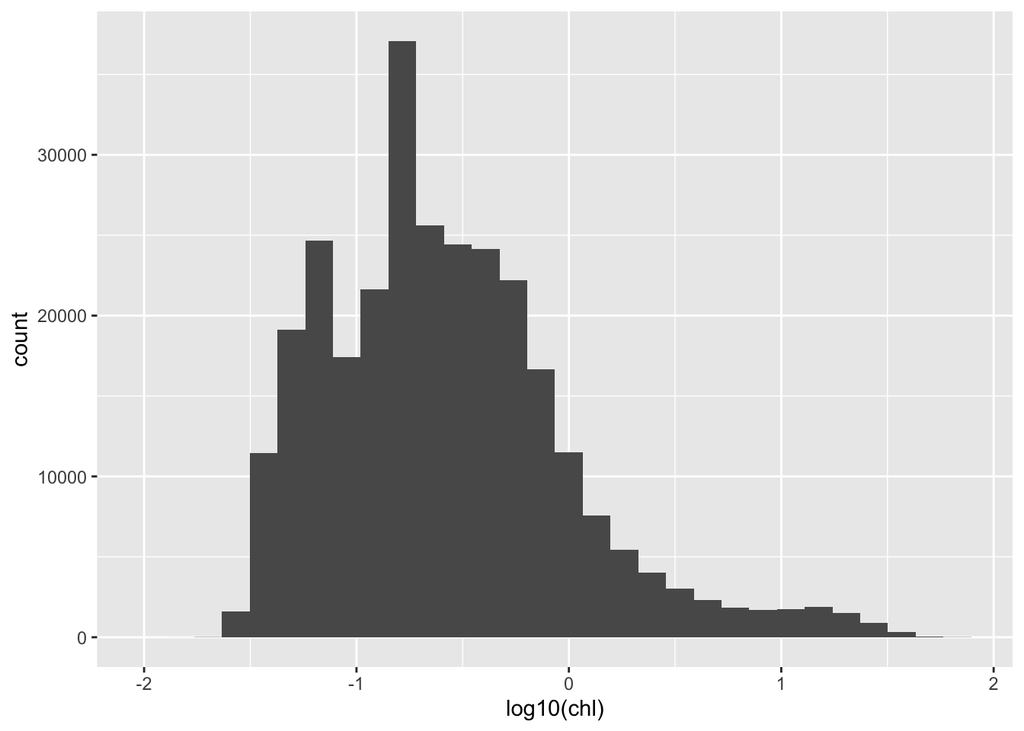

```r
result1 %>%
  ggplot(aes(x=log10(chl))) + geom_histogram()
```

It’s log-normal, but there are several peaks. Perhaps breaking up by time of year or latitude will decompose the peaks.

```r
library(lubridate)
library(ggridges)
```

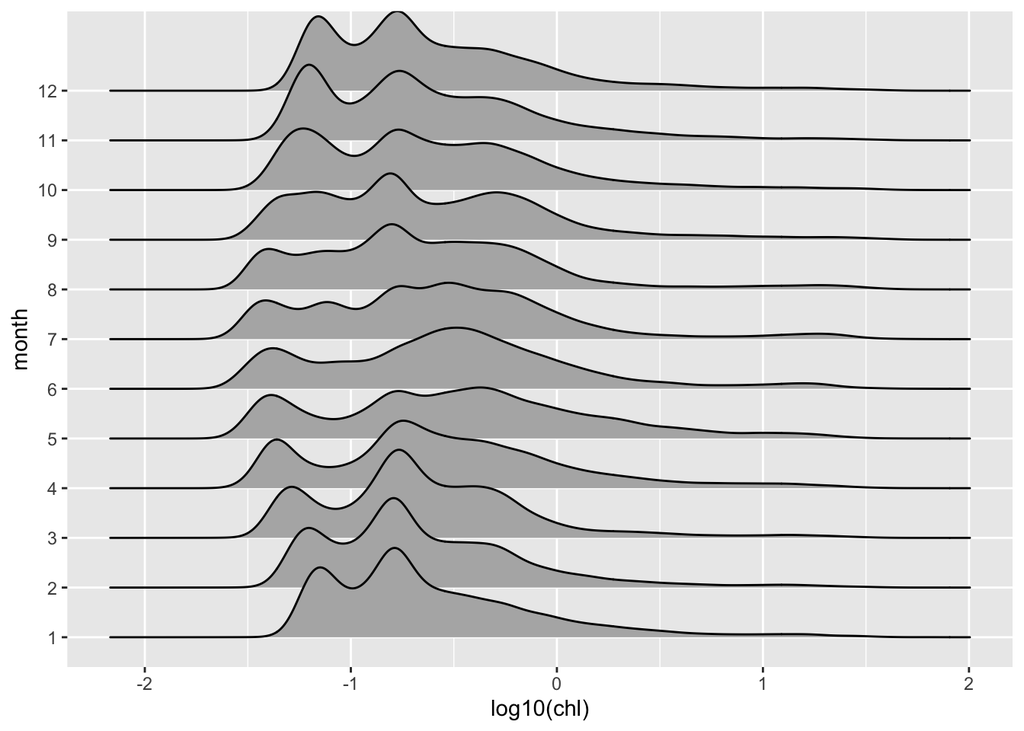

```r
result1 %>%
  mutate(month = factor(month(time))) %>%
  ggplot(aes(x = log10(chl), y=month)) +
  geom_density_ridges()
```

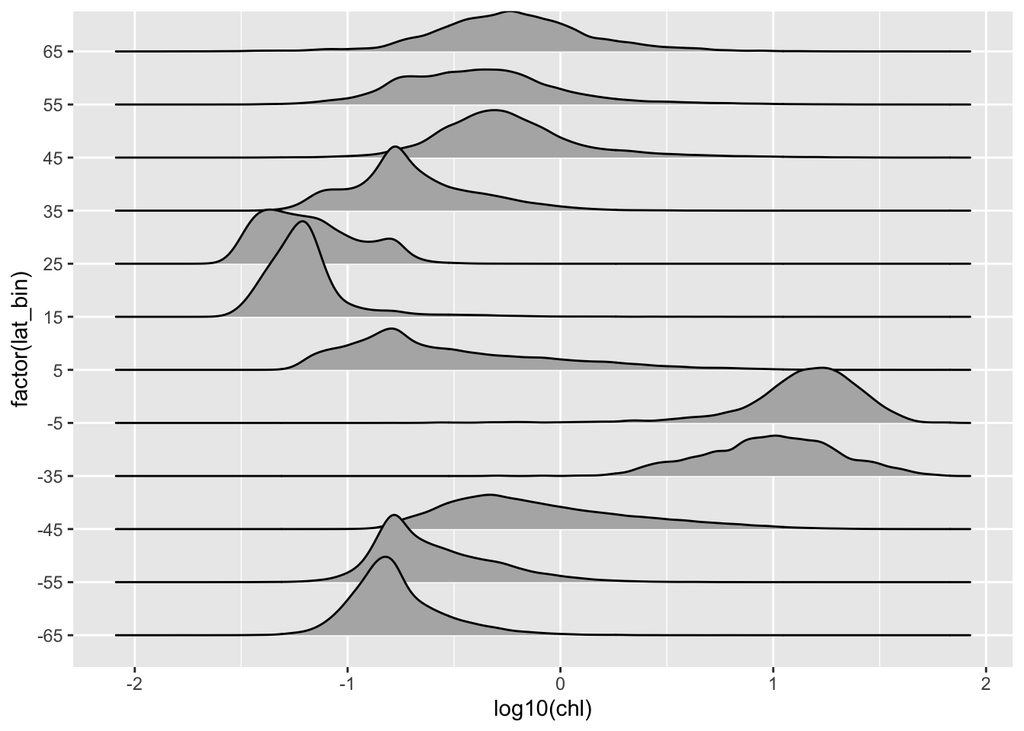

```r
result1 %>%
  mutate(lat_bin = floor((lat-5)/10)*10+5) %>%
  ggplot(aes(x = log10(chl), y=factor(lat_bin))) +
  geom_density_ridges()
```

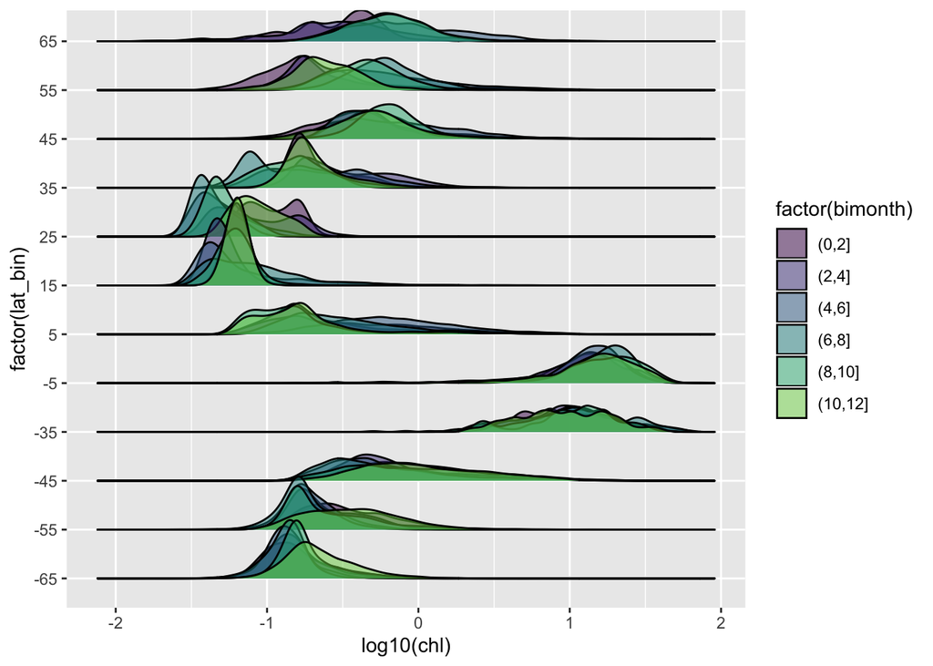

```r
result1 %>%
  mutate(lat_bin = floor((lat-5)/10)*10+5,
         quarter = quarter(time),
         bimonth = cut(month(time), 2*(0:6))) %>%
  ggplot(aes(x = log10(chl), y=factor(lat_bin), fill=factor(bimonth))) +
  geom_density_ridges() +
  scale_fill_viridis_d(end=0.8, alpha=0.5)
```

Make 2d histogram - chl over lat x day

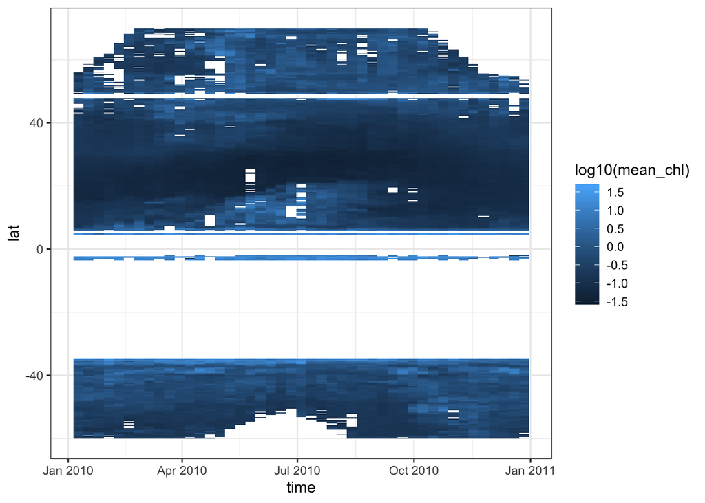

```r
result1 %>%
  filter(time > "2010-01-01", time < "2010-12-31") %>%
  group_by(time, lat) %>%
  summarize(mean_chl = mean(chl, na.rm=TRUE)) %>%
  ggplot(aes(x=time, y=lat, fill=log10(mean_chl))) + geom_tile() +
  theme_bw()
```

Help I found useful:

- https://docs.microsoft.com/en-us/sql/t-sql/functions/grouping-transact-sql?view=sql-server-ver15